# Reanalysis for Problem Set 2

Erin Bennett

February 16, 2016

**Caveat:** I probably made mistakes in this code…

**Fact:** [Sklar et al. (2012)](http://www.pnas.org/content/109/48/19614.full) find that for their subtraction problems, reaction time is lower for primed targets than unprimed targets.

# Experiment 6

## Design

For each prime, there were as many congruent targets as there were incongruent targets (though when we filter out datapoints where the reaction time was actually recorded, we get slight asymmetries). However, the result of the primes were different for the different operations, and the subtraction results were skewed to be close to (and frequently equal to) zero.

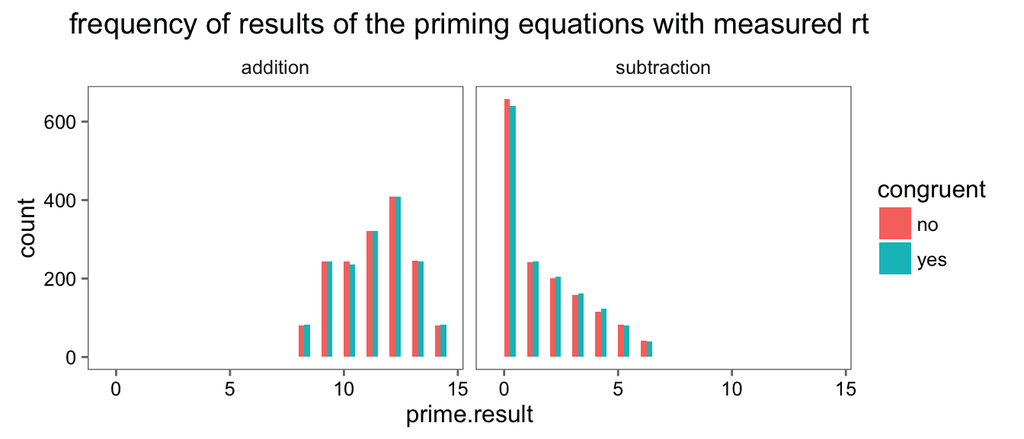

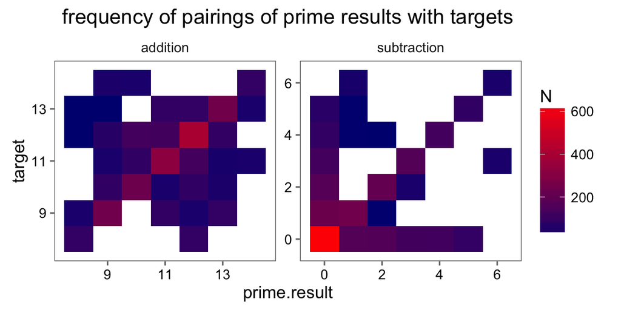

## Problems with zero trials?

**Hypothesis based on design:** Maybe the effect is driven by trials where the prime.result is 0?

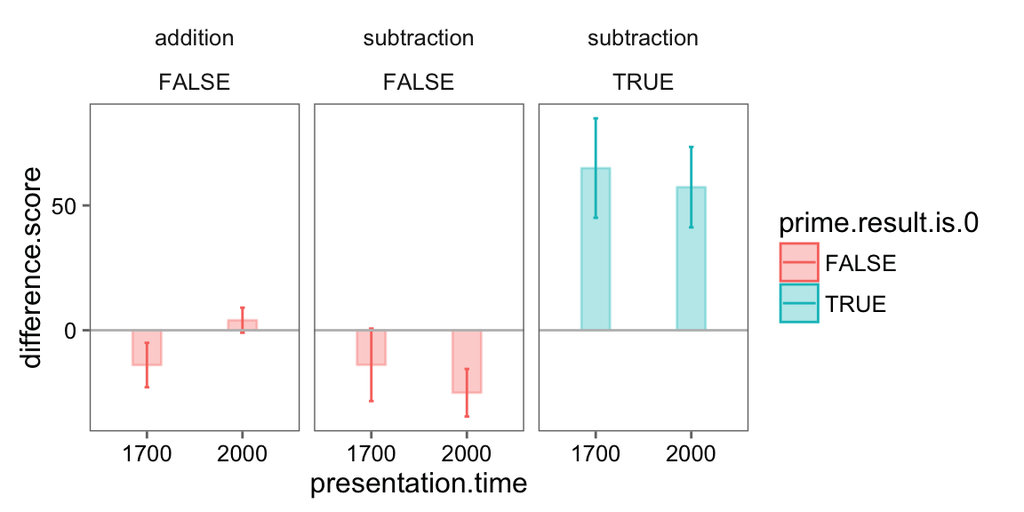

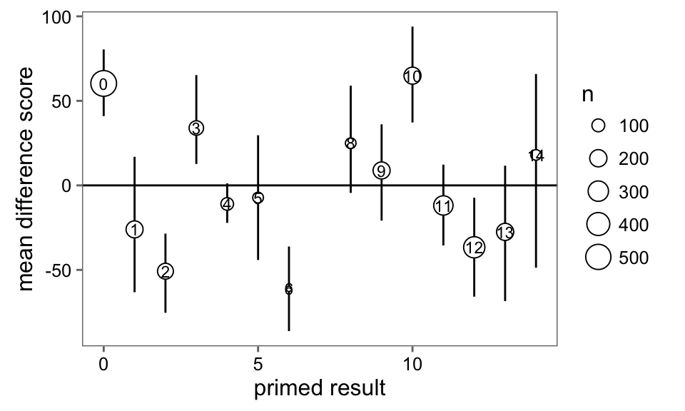

The results look similar whether or not we use Sklar et al’s exclusion criteria: unfiltered.

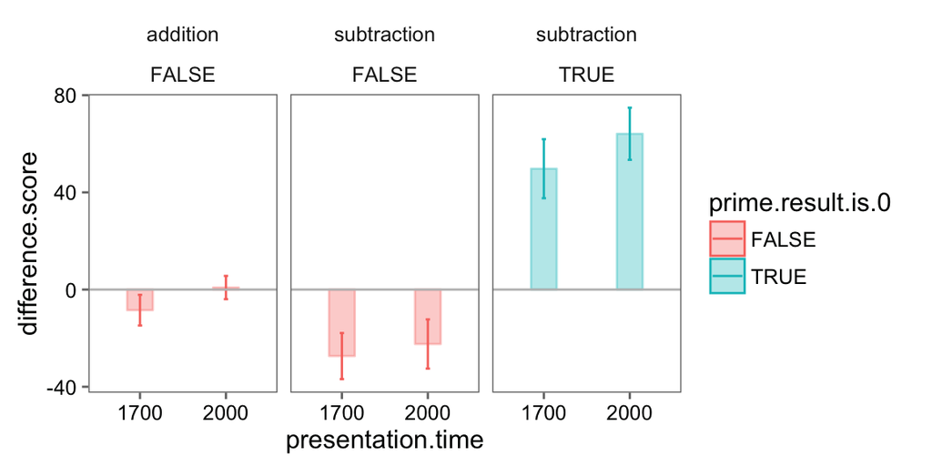

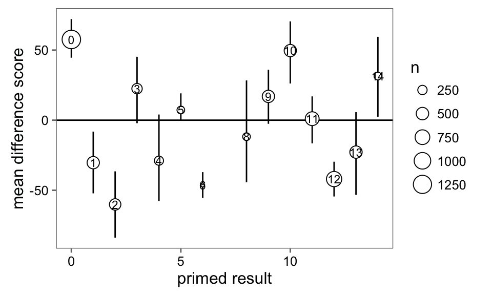

## Easiness of prime?

**Hypothesis about mechanism:** Does the “easiness” of the prime predict to the fascilitation effect?

Well, the other highest difference scores are when the answer is 10, which also seems easy…

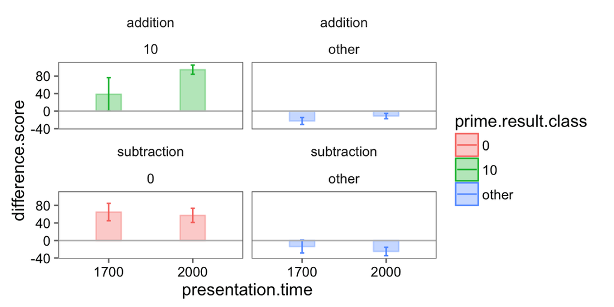

We could go on mturk and get the time it takes to solve each of these priming equations. Does that easiness correlate with the difference score?

# Experiment 7

## Design

The design of experiment 7 was much more balanced.

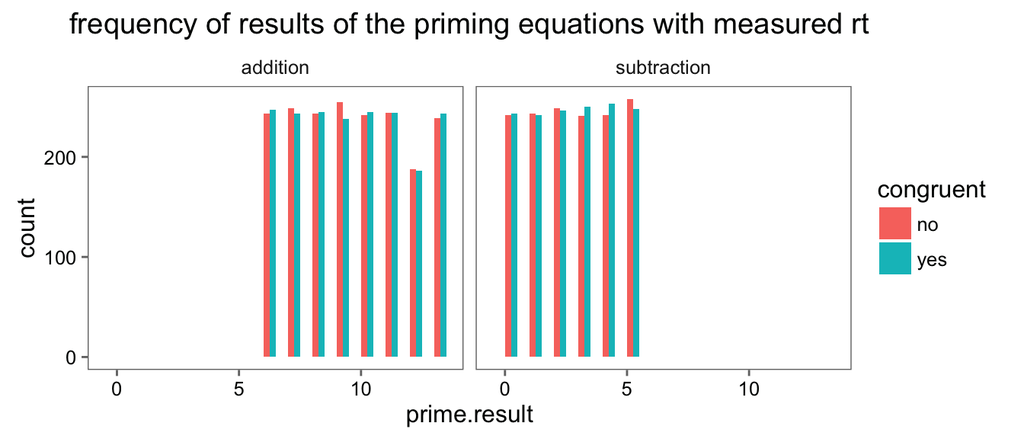

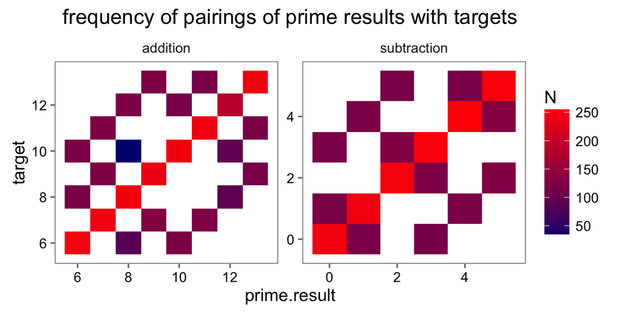

## Effects

When we don’t exlude we see the effect of 0.

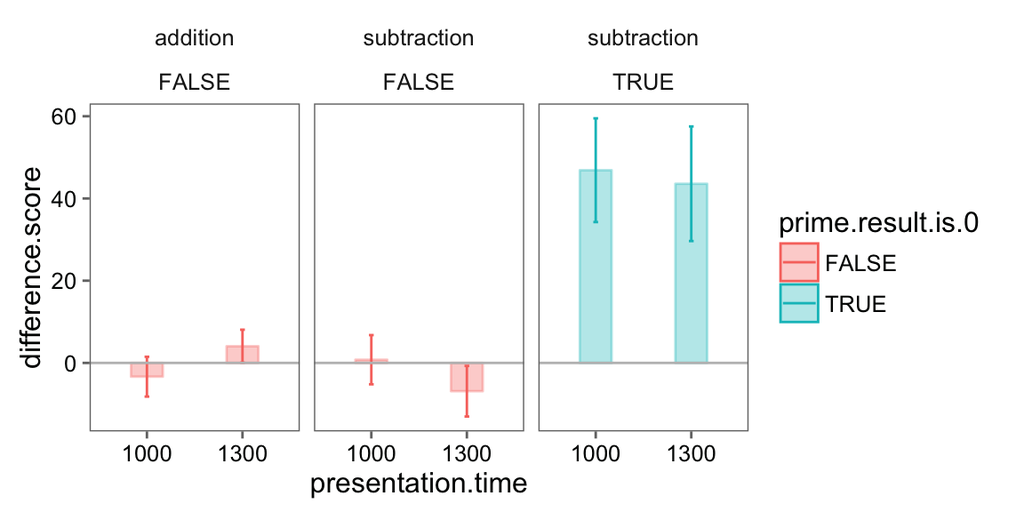

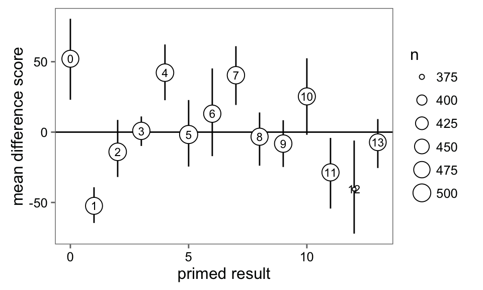

Same when we do exclude, but less strong.

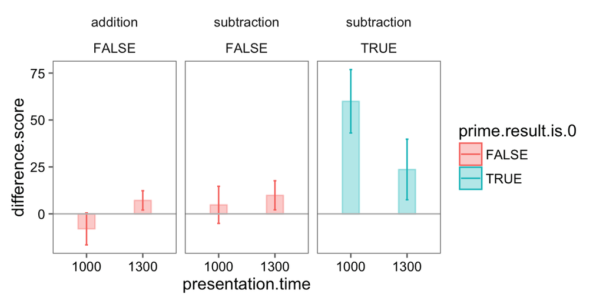

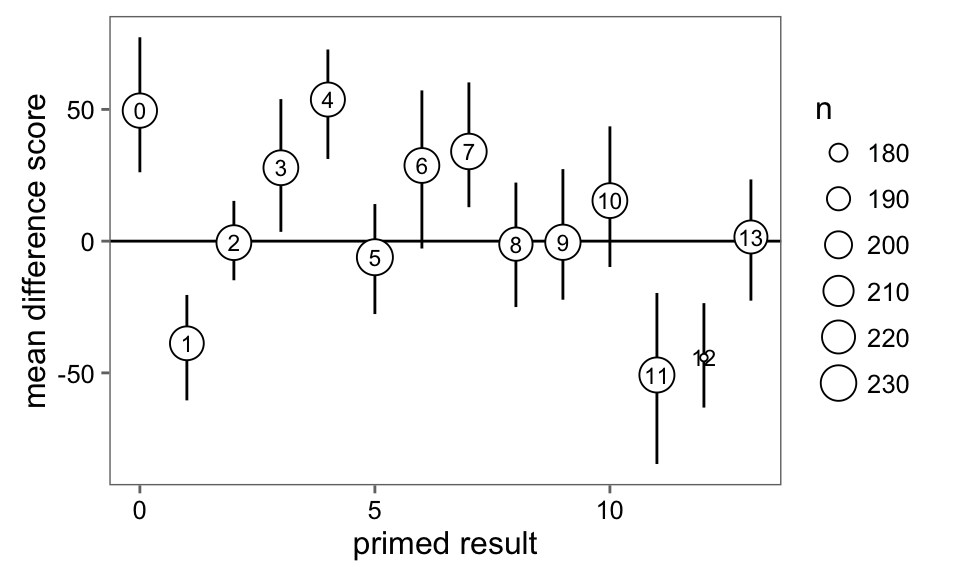

10 has a lower fasciliation effect than in experiment 6.

# Cross-experiments

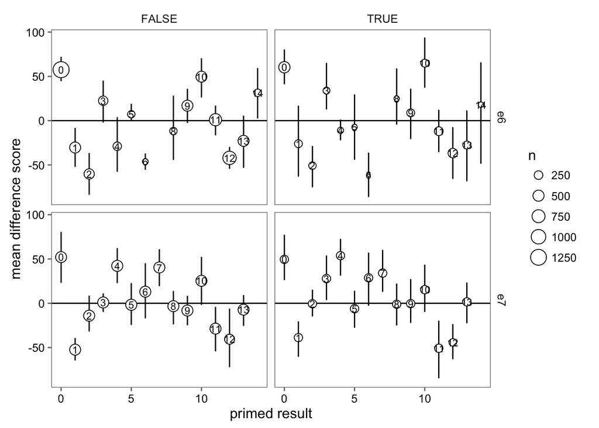

Not much correlation between experiments in individual values. With exclusions:

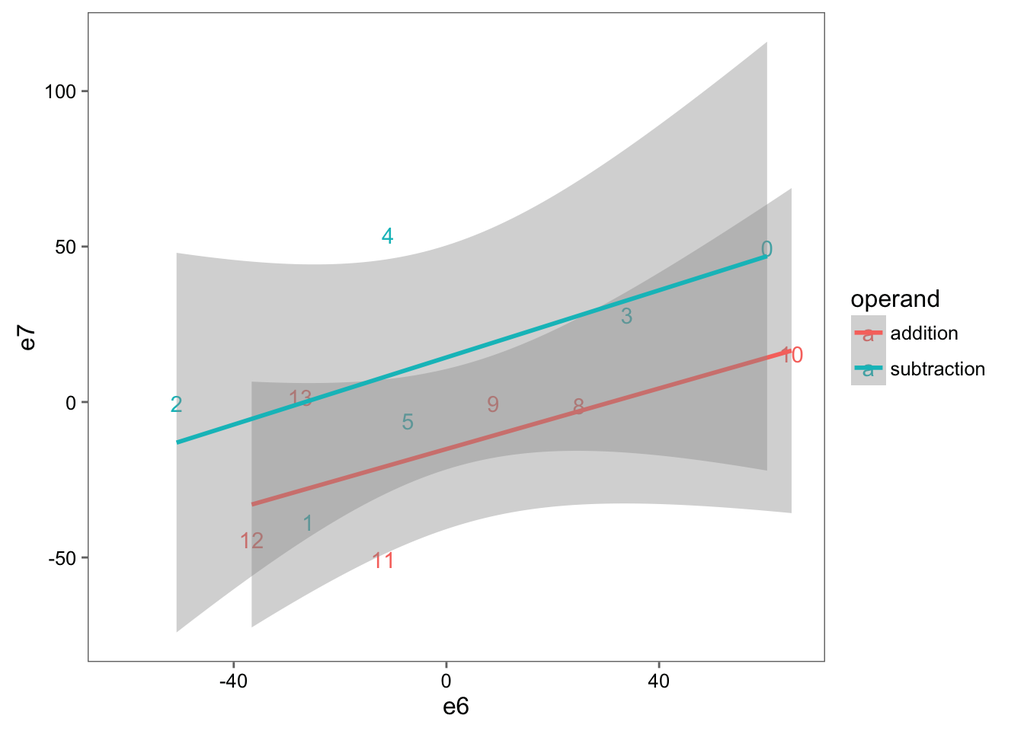

Without.

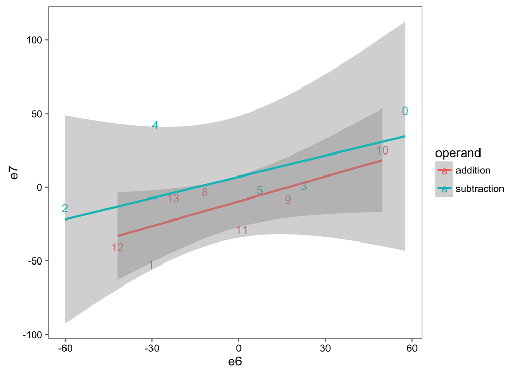